# R Notebook Bike case study

Uploaded cvs data in R studio then migrated it to enviroment panel

```r
data_Q1 <- read_csv("Divvy_Trips_2019_Q2.csv")
data_Q2 <- read_csv("Divvy_Trips_2019_Q3.csv")
data_Q3 <- read_csv("Divvy_Trips_2019_Q4.csv")
data_Q4 <- read_csv("Divvy_Trips_2020_Q1.csv")
```

Rename columns data_Q1

```r
(data_Q1 <- rename(data_Q1
                   ,ride_id = "01 - Rental Details Rental ID"
                   ,rideable_type = "01 - Rental Details Bike ID"
                   ,started_at = "01 - Rental Details Local Start Time"
                   ,ended_at = "01 - Rental Details Local End Time"
                   ,start_station_name = "03 - Rental Start Station Name"
                   ,start_station_id = "03 - Rental Start Station ID"
                   ,end_station_name = "02 - Rental End Station Name"
                   ,end_station_id = "02 - Rental End Station ID"
                   ,member_casual = "User Type"))
```

Rename columns data_Q2

```r
(data_Q2 <- rename(data_Q2
                   ,ride_id = trip_id
                   ,rideable_type = bikeid
                   ,started_at = start_time
                   ,ended_at = end_time
                   ,start_station_name = from_station_name
                   ,start_station_id = from_station_id
                   ,end_station_name = to_station_name
                   ,end_station_id = to_station_id
                   ,member_casual = usertype))
```

Rename columns data_Q3

```r
(data_Q3 <- rename(data_Q3
                  ,ride_id = trip_id
                  ,rideable_type = bikeid
                  ,started_at = start_time
                  ,ended_at = end_time
                  ,start_station_name = from_station_name
                  ,start_station_id = from_station_id
                  ,end_station_name = to_station_name
                  ,end_station_id = to_station_id
                  ,member_casual = usertype))
```

Convert ride_id and rideable_type to character so that they can stack correctly

```r
data_Q3 <-  mutate(data_Q3, ride_id = as.character(ride_id)
                   ,rideable_type = as.character(rideable_type))
data_Q2 <-  mutate(data_Q2, ride_id = as.character(ride_id)
                   ,rideable_type = as.character(rideable_type))
data_Q1 <-  mutate(data_Q1, ride_id = as.character(ride_id)
                   ,rideable_type = as.character(rideable_type))
data_Q4 <-  mutate(data_Q4, started_at = as.POSIXct(started_at)
                   ,ended_at = as.POSIXct(ended_at))
```

Stack individual quarter’s data frames into one big data frame

```r
all_trips <- bind_rows(data_Q1, data_Q2, data_Q3, data_Q4)
```

Remove lat, long, birthyear, and gender fields as this data was dropped beginning in 2020

```r
all_trips <- all_trips %>%
  select(-c(start_lat, start_lng, end_lat, end_lng, birthyear, gender, "01 - Rental Details Duration In Seconds Uncapped", "05 - Member Details Member Birthday Year", "Member Gender", "tripduration"))
```

Clean and add data to prepare for analysis

```r
colnames(all_trips)  #List of column names
```

[output not shown]

```r
nrow(all_trips)  #How many rows are in data frame?
```

```
[1] 3879822
```

```r
dim(all_trips)  #Dimensions of the data frame?
```

[output not shown]

```r
head(all_trips)  #See the first 6 rows of data frame.  Also tail(qs_raw)
```

[output not shown]

```r
str(all_trips)  #See list of columns and data types (numeric, character, etc)
```

[output not shown]

```r
summary(all_trips)  #Statistical summary of data. Mainly for numeric
```

[output not shown]

In the “member_casual” column, replace “Subscriber” with “member” and “Customer” with “casual”

```r
all_trips <-  all_trips %>%
  mutate(member_casual = recode(member_casual
                           ,"Subscriber" = "member"
                           ,"Customer" = "casual"))
```

Add columns that list the date, month, day, and year of each ride

```r
all_trips$date <- as.Date(all_trips$started_at) #The default format is yyyy-mm-dd
all_trips$month <- format(as.Date(all_trips$date), "%m")
all_trips$day <- format(as.Date(all_trips$date), "%d")
all_trips$year <- format(as.Date(all_trips$date), "%Y")
all_trips$day_of_week <- format(as.Date(all_trips$date), "%A")
all_trips$ride_length <- difftime(all_trips$ended_at,all_trips$started_at) # Add a "ride_length" calculation to all_trips (in seconds)
```

Convert “ride_length” from Factor to numeric so we can run calculations on the data

```r
is.factor(all_trips$ride_length)
all_trips$ride_length <- as.numeric(as.character(all_trips$ride_length))
is.numeric(all_trips$ride_length)
```

Remove “bad” data

```r
all_trips_v2 <- all_trips[!(all_trips$start_station_name == "HQ QR" | all_trips$ride_length<0),]
```

Descriptive analysis on ride_length (all figures in seconds)

```r
mean(all_trips_v2$ride_length) #straight average (total ride length / rides)
```

```
[1] 15831.09
```

```r
median(all_trips_v2$ride_length) #midpoint number in the ascending array of ride lengths
```

```
[1] 715
```

```r
max(all_trips_v2$ride_length) #longest ride
```

```
[1] 946683900
```

```r
min(all_trips_v2$ride_length) #shortest ride
```

```
[1] 0
```

```r
summary(all_trips_v2$ride_length)
```

```
     Min.   1st Qu.    Median      Mean   3rd Qu.      Max.
        0       415       715     15831      1289 946683900
```

Compare members and casual users

```r
aggregate(all_trips_v2$ride_length ~ all_trips_v2$member_casual, FUN = mean)
```

| all_trips_v2$member_casual | all_trips_v2$ride_length |
| --- | --- |
| casual | 45129.487 |
| member | 6943.314 |

```r
aggregate(all_trips_v2$ride_length ~ all_trips_v2$member_casual, FUN = median)
```

| all_trips_v2$member_casual | all_trips_v2$ride_length |
| --- | --- |
| casual | 1547 |
| member | 592 |

```r
aggregate(all_trips_v2$ride_length ~ all_trips_v2$member_casual, FUN = max)
```

| all_trips_v2$member_casual | all_trips_v2$ride_length |
| --- | --- |
| casual | 946683900 |
| member | 820461300 |

```r
aggregate(all_trips_v2$ride_length ~ all_trips_v2$member_casual, FUN = min)
```

| all_trips_v2$member_casual | all_trips_v2$ride_length |
| --- | --- |
| casual | 0 |
| member | 0 |

See the average ride time by each day for members vs casual users

```r
aggregate(all_trips_v2$ride_length ~ all_trips_v2$member_casual + all_trips_v2$day_of_week, FUN = mean)
```

| all_trips_v2$member_casual | all_trips_v2$day_of_week | all_trips_v2$ride_length |
| --- | --- | --- |
| casual | Sunday | 38982.542 |
| member | Sunday | 8232.948 |
| casual | Monday | 40417.551 |
| member | Monday | 5489.154 |
| casual | Tuesday | 94940.426 |
| member | Tuesday | 5936.529 |
| casual | Wednesday | 63238.070 |
| member | Wednesday | 10128.040 |
| casual | Thursday | 56308.738 |
| member | Thursday | 6030.037 |

[output cut: 4 more lines]

Analyze ridership data by type and weekday

```r
all_trips_v2 %>%
  mutate(weekday = wday(started_at, label = TRUE)) %>%  #creates weekday field using wday()
  group_by(member_casual, weekday) %>%  #groups by usertype and weekday
  summarise(number_of_rides = n()                           #calculates the number of rides and average duration
  ,average_duration = mean(ride_length)) %>%        # calculates the average duration
  arrange(member_casual, weekday)   # sorts
```

| member_casual | weekday | number_of_rides | average_duration |
| --- | --- | --- | --- |
| casual | Sun | 171789 | 38982.542 |
| casual | Mon | 105931 | 40417.551 |
| casual | Tue | 95593 | 94940.426 |
| casual | Wed | 93117 | 63238.070 |
| casual | Thu | 108390 | 56308.738 |
| casual | Fri | 120920 | 32572.807 |
| casual | Sat | 206386 | 22908.785 |
| member | Sun | 294968 | 8232.948 |
| member | Mon | 460257 | 5489.154 |
| member | Tue | 499351 | 5936.529 |

[output cut: 4 more lines]

Let’s visualize the number of rides by rider type

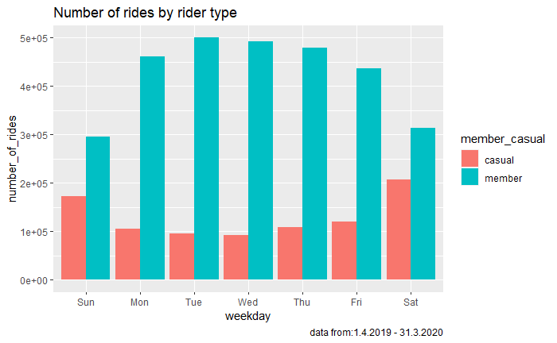

```r
all_trips_v2 %>%
  mutate(weekday = wday(started_at, label = TRUE)) %>%
  group_by(member_casual, weekday) %>%
  summarise(number_of_rides = n()
            ,average_duration = mean(ride_length)) %>%
  arrange(member_casual, weekday)  %>%
  ggplot(aes(x = weekday, y = number_of_rides, fill = member_casual)) +
  geom_col(position = "dodge")+
  theme(axis.text.x = element_text())+
  labs(title = "Number of rides by rider type", caption = paste0("data from:1.4.2019 - 31.3.2020"))
```

Creating csv file with columns ride_length, member_casual and day_of_week-mean

```r
counts <- aggregate(all_trips_v2$ride_length ~ all_trips_v2$member_casual + all_trips_v2$day_of_week, FUN = mean)
write.csv(counts, 'C:/Users/Gundul/Desktop/Exercise/avg_ride_length2.csv', row.names = TRUE)
```